# Study 2 on its own: figures for talks

Retribution study, N = 948

David G. Kamper

22 September 2026

# What this document does

The paper’s figures either show Study 1 alone or set the two studies side by side. This document draws figures from **Study 2 alone**, one per slide, for presenting the study in a talk. It covers the replication results (Part 1 of Study 2’s Results) and the results on what people mean by retribution (Part 2).

**Design.** Every slide is 16:9, in grayscale, with a short centered title. Distributions are shown as violin plots (the shape of everyone’s answers, with each participant as a jittered point and the mean and its 95% confidence interval on top); correlations, shares, and counts are shown as bar charts. The takeaway of each slide is left to the speaker.

**Reads.** Study 2’s scored data and the tables `01_main_analysis.Rmd` exported. Nothing here changes the analysis.

**Computes.** Only what a figure needs and the analysis did not export in the form a figure needs: answer distributions, a few confidence intervals, and the comparison of hostility and crime concerns on each separate part of punitiveness, using the registered clusters. Every number that also exists in the analysis of record is checked against it by a guard, and the knit stops if any guard fails.

**Writes.** Thirteen figures, each as PNG (for slides) and PDF (for print), to `output/figures/study2_talk/`, with a copy of each PNG in `Docs/Writing/figures/study2_talk/`. One table, `output/tables/study2_talk_figure_values.csv`, lists every value each figure plots, so a speaker can quote any number on a slide from one place.

**Run order.** Knit `01_main_analysis.Rmd` first. This document reads its exports and stops if any is missing.

# 1. Paths, packages, and inputs

```r
# === PATHS AND INPUT CHECKS ===
# WHAT THIS CHUNK DOES: names every input and output, loads the packages, reads
# the scored data, and stops if any export the figures need is missing.
#
# PATHS ARE RELATIVE to this document's folder, like the other documents here.
S2_TABLES   <- file.path("output", "tables")
S2_DATA     <- file.path("data", "cleaned", "retribution_scored.rds")
OUT_FIGURES <- file.path("output", "figures", "study2_talk")
OUT_TABLES  <- file.path("output", "tables")
# A copy of every PNG goes to the manuscript's figure folder, beside the paper's
# own figures, so the slides and the paper draw on the same files.
DOCS_FIG    <- file.path("..", "..", "Docs", "Writing", "figures", "study2_talk")
dir.create(OUT_FIGURES, recursive = TRUE, showWarnings = FALSE)
dir.create(DOCS_FIG, recursive = TRUE, showWarnings = FALSE)
# CLEAR THIS DOCUMENT'S OLD SLIDES FIRST. Every file named s2_*.png or s2_*.pdf
# in these two folders is written by this document and nothing else. Removing
# them before drawing means a slide dropped or renamed in a later version cannot
# linger beside the current set and be mistaken for part of it.
unlink(list.files(OUT_FIGURES, pattern = "^s2_.*\\.(png|pdf)$", full.names = TRUE))
unlink(list.files(DOCS_FIG, pattern = "^s2_.*\\.png$", full.names = TRUE))

# Every export read below. A missing file means 01_main_analysis.Rmd has not
# been knitted since the section that writes it was added; knit it first.
S2_NEEDED <- c("descriptives", "sentence_ceiling_share", "H1_correlations",
               "H2_steiger", "DS_sentence_steiger", "goal_rank_matrix",
               "goal_subscales", "H4_midpoint_tests", "H4_shares", "H5_paired",
               "H6b_desert_principle_vs_severity", "H1_companion_severity",
               "P2_goals_by_limits", "H9_paired", "H10r_revenge_versions",
               "P2_H10_vs_desert", "P2_sentence_ceiling", "P2_sentence_change",
               "sentencing_ratio_direction_cells", "sentencing_ratio_correlates",
               "contrasts_continuous_ratio")
S2_MISSING <- S2_NEEDED[!file.exists(file.path(S2_TABLES,
                                               paste0(S2_NEEDED, ".csv")))]
if (length(S2_MISSING)) stop("Knit 01_main_analysis.Rmd first. Missing: ",
                             paste(S2_MISSING, collapse = ", "))
stopifnot(file.exists(S2_DATA))

library(ggplot2)

d <- as.data.frame(readRDS(S2_DATA))
read_s2 <- function(name) read.csv(file.path(S2_TABLES, paste0(name, ".csv")),
                                   stringsAsFactors = FALSE)
stopifnot(nrow(d) == 948)
cat(sprintf("Study 2: %d participants.\n", nrow(d)))
```

```
## Study 2: 948 participants.
```

# 2. Shared tools: style, grays, intervals, and a guard

```r
# === ONE STYLE FOR EVERY SLIDE ===
# SLIDE SIZE. 13.333 x 7.5 inches is the standard 16:9 PowerPoint and Keynote
# slide, so a figure dropped onto a blank slide fills it at full size and the
# type prints at the size set here. PNGs are written at 200 dpi (2667 x 1500
# pixels), sharp on a projector without making the files large.
SLIDE_W <- 13.333; SLIDE_H <- 7.5; SLIDE_DPI <- 200

# GRAYSCALE. Every slide uses grays only, so the figures read the same on any
# projector, in print, and to a viewer who cannot tell colours apart. When a
# slide compares categories, they are told apart by shade, and every shade is
# also named in a legend or by a label on the bar itself.
# The four data grays form one light-to-dark ramp. The data-visualization
# palette validator confirmed that each step is visibly darker than the one
# before it and that the lightest still stands out against the white slide.
G1 <- "#1a1a1a"   # darkest: the series the slide is about
G2 <- "#404040"
G3 <- "#737373"
G4 <- "#b0b0b0"   # lightest data gray
# Two evenly spaced ramps for stacked bars, where neighbouring segments touch
# and must be told apart at a glance (also validated, light to dark):
RAMP4 <- c("#1a1a1a", "#4f4f4f", "#808080", "#b0b0b0")   # 1st to 4th place
RAMP3 <- c("#b0b0b0", "#666666", "#1a1a1a")              # reduced, kept, raised
FILL_VIOLIN <- "#d9d9d9"   # violin bodies: light, so the mean marks stand out
INK   <- "#000000"   # titles and values
INK2  <- "#404040"   # axis text
MUTED <- "#7a7a7a"   # captions and reference lines
GRID  <- "#e6e6e6"   # hairline gridlines
BAND  <- "#eeeeee"   # shaded reference band

theme_slide <- function() {
  theme_minimal(base_size = 20, base_family = "sans") +
    theme(text = element_text(colour = INK),
          # SHORT, CENTERED TITLES. hjust = 0.5 centers the title; with
          # plot.title.position = "plot" it is centered on the whole slide,
          # not just on the plotting area.
          plot.title = element_text(face = "bold", size = 30, hjust = 0.5,
                                    margin = margin(b = 18)),
          plot.caption = element_text(size = 13, colour = MUTED, hjust = 0.5,
                                      margin = margin(t = 16), lineheight = 1.1),
          plot.title.position = "plot", plot.caption.position = "plot",
          axis.text = element_text(colour = INK2, size = 18),
          axis.title = element_text(colour = INK2, size = 18),
          axis.title.x = element_text(margin = margin(t = 10)),
          axis.title.y = element_text(margin = margin(r = 10)),
          panel.grid.minor = element_blank(),
          legend.position = "top", legend.justification = "center",
          legend.title = element_blank(),
          legend.text = element_text(size = 18, colour = INK2),
          legend.key.size = unit(1.1, "lines"),
          plot.margin = margin(26, 40, 18, 30))
}
# Horizontal bars: gridlines run up the value axis only.
theme_hbar <- function() theme_slide() +
  theme(panel.grid.major.y = element_blank(),
        panel.grid.major.x = element_line(colour = GRID, linewidth = 0.5),
        axis.text.y = element_text(colour = INK, size = 19))
# Vertical bars and violins: gridlines run across the value axis only.
theme_vbar <- function() theme_slide() +
  theme(panel.grid.major.x = element_blank(),
        panel.grid.major.y = element_line(colour = GRID, linewidth = 0.5),
        axis.text.x = element_text(colour = INK, size = 19))

# Correlations print without the leading zero (.71, not 0.71), as in the paper,
# and negative values take a true minus sign. A correlation smaller than .01 in
# size would print as .00 or .01 at two decimals, which misstates it, so it gets
# three decimals (.007).
fmt_r <- function(x, digits = 2) {
  dg <- ifelse(abs(x) < 0.01, 3, digits)
  s <- vapply(seq_along(x), function(i) formatC(x[i], format = "f", digits = dg[i]),
              character(1))
  s <- sub("^(-?)0\\.", "\\1.", s)
  sub("^-", "−", s)
}
axis_r <- function(x) sub("^-", "−", sub("^(-?)0\\.", "\\1.", sprintf("%.1f", x)))
# CAPTIONS are wrapped to the slide width, so none runs off the edge.
cap <- function(...) paste(strwrap(paste(...), width = 140), collapse = "\n")

# PEARSON r WITH ITS 95% INTERVAL. cor.test() gives the Fisher-z interval, the
# interval the main analysis uses for every correlation.
cor_ci <- function(x, y) {
  tt <- cor.test(x, y)
  data.frame(r = unname(tt$estimate), lower = tt$conf.int[1],
             upper = tt$conf.int[2], n = sum(complete.cases(x, y)))
}
# A 95% interval for a mean.
mean_ci <- function(x) {
  tt <- t.test(x)
  data.frame(mean = mean(x), lower = tt$conf.int[1], upper = tt$conf.int[2],
             n = length(x))
}
# GUARD: two numbers must agree to within a tolerance, or the knit stops with a
# message naming the check.
same <- function(a, b, what, tol = 1e-8) {
  if (!isTRUE(all.equal(as.numeric(a), as.numeric(b), tolerance = tol)))
    stop("Guard failed: ", what, " (", paste(signif(a, 6), collapse = ", "),
         " vs ", paste(signif(b, 6), collapse = ", "), ")")
  invisible(TRUE)
}

# EVERY PLOTTED VALUE is collected here and written to one table at the end.
VALUES <- list()
keep_values <- function(fig, df) VALUES[[fig]] <<- cbind(figure = fig, df)

save_slide <- function(p, name) {
  png_path <- file.path(OUT_FIGURES, paste0(name, ".png"))
  ggsave(png_path, p, width = SLIDE_W, height = SLIDE_H, dpi = SLIDE_DPI,
         bg = "white")
  ggsave(file.path(OUT_FIGURES, paste0(name, ".pdf")), p,
         width = SLIDE_W, height = SLIDE_H, bg = "white")
  file.copy(png_path, file.path(DOCS_FIG, basename(png_path)), overwrite = TRUE)
}

# HORIZONTAL BAR CHART OF CORRELATIONS, used by several slides. One bar per
# row, the value printed past the end of its interval. `fill` names the column
# that sets each bar's gray; `dodge` > 0 sets two bars per row side by side.
# coord_cartesian() zooms the axis without dropping any interval that runs past
# its ends (scale limits would silently delete such an interval).
bar_r <- function(df, y, fill, fills, xlim, xbreaks, xlab, dodge = 0) {
  pos <- if (dodge > 0) position_dodge(width = dodge) else position_identity()
  ggplot(df, aes(x = r, y = .data[[y]], fill = .data[[fill]])) +
    geom_col(width = if (dodge > 0) dodge * 0.95 else 0.68, position = pos) +
    geom_errorbar(aes(xmin = lower, xmax = upper), width = 0.22,
                  orientation = "y", linewidth = 0.7, colour = INK, position = pos) +
    geom_text(aes(x = pmax(upper, 0) + 0.012, label = fmt_r(r)), hjust = 0,
              size = 6, colour = INK, position = pos, show.legend = FALSE) +
    geom_vline(xintercept = 0, colour = INK2, linewidth = 0.6) +
    scale_fill_manual(values = fills) +
    scale_x_continuous(breaks = xbreaks, labels = axis_r) +
    coord_cartesian(xlim = xlim, clip = "off") +
    labs(x = xlab, y = NULL) +
    theme_hbar()
}

# VIOLIN PLOT OF 1-TO-7 SCORES, used by two slides. The violin is the shape of
# everyone's answers (wider where more people answered); the black point is
# the mean and the black bar its 95% interval; the dashed line is the neutral
# midpoint of the scale.
violin_1to7 <- function(long, stats, x_levels) {
  long$measure  <- factor(long$measure, levels = x_levels)
  stats$measure <- factor(stats$measure, levels = x_levels)
  ggplot(long, aes(x = measure, y = score)) +
    geom_hline(yintercept = 4, linetype = "dashed", colour = MUTED, linewidth = 0.6) +
    geom_violin(fill = FILL_VIOLIN, colour = G3, linewidth = 0.6, width = 0.85,
                scale = "width", adjust = 1.2, trim = TRUE) +
    # EACH POINT IS ONE PARTICIPANT, spread sideways at random so that people
    # with the same score do not sit on top of one another. The spread is
    # sideways only, so every point stays at the participant's score; the seed
    # fixes the spread, so every knit draws the same slide.
    geom_point(position = position_jitter(width = 0.22, height = 0, seed = 1),
               size = 1.1, alpha = 0.3, colour = G3, stroke = 0) +
    geom_errorbar(data = stats, aes(x = measure, ymin = lower, ymax = upper),
                  inherit.aes = FALSE, width = 0.12, linewidth = 1, colour = INK) +
    geom_point(data = stats, aes(x = measure, y = mean), inherit.aes = FALSE,
               size = 5, colour = INK) +
    geom_label(data = stats, aes(x = measure, y = mean, label = sprintf("%.2f", mean)),
               inherit.aes = FALSE, nudge_x = 0.2, hjust = 0, size = 6,
               label.size = 0, fill = "white", label.padding = unit(0.15, "lines")) +
    scale_y_continuous(breaks = 1:7, limits = c(1, 7),
                       labels = c("1\nStrongly\ndisagree", "2", "3", "4\nNeutral",
                                  "5", "6", "7\nStrongly\nagree")) +
    labs(x = NULL, y = NULL) +
    theme_vbar() +
    theme(axis.text.y = element_text(size = 15, lineheight = 0.9))
}
```

# 3. The sentencing decision

```r
# === SLIDE 1: THE FIRST SENTENCE (BAR CHART) ===
# The share of participants choosing each number of years for the second-degree
# murder, 0 to 50 (50 = life). The shaded band is the range the instructions
# gave ("Most sentences given by judges for similar charges range from 20 to 30
# years"); the dashed line is the mean.
s1 <- d$Sentence1
stopifnot(!anyNA(s1), length(s1) == 948)
desc <- read_s2("descriptives")
same(mean(s1), desc$mean[desc$variable == "Sentence1"], "mean first sentence")
same(sd(s1),   desc$sd[desc$variable == "Sentence1"],   "SD first sentence")
ceil <- read_s2("sentence_ceiling_share")
same(mean(s1 == 50), ceil$prop[1], "share choosing 50 years")
share_above_30 <- mean(s1 > 30)
cat(sprintf("Mean %.1f years; %.1f%% chose 50; %.1f%% chose more than 30.\n",
            mean(s1), 100 * mean(s1 == 50), 100 * share_above_30))
```

```
## Mean 36.2 years; 38.0% chose 50; 54.7% chose more than 30.
```

```r
sent_tab <- data.frame(years = 0:50,
                       pct = 100 * as.numeric(table(factor(s1, levels = 0:50))) / length(s1))
top <- max(sent_tab$pct)
fig01 <- ggplot(sent_tab, aes(years, pct)) +
  annotate("rect", xmin = 19.5, xmax = 30.5, ymin = -Inf, ymax = Inf,
           fill = BAND, colour = NA) +
  annotate("text", x = 25, y = top * 0.98, label = "Typical range\n20 to 30 years",
           size = 6, colour = INK2, lineheight = 0.95, vjust = 1) +
  geom_col(width = 0.8, fill = G3) +
  geom_vline(xintercept = mean(s1), linetype = "dashed", colour = INK, linewidth = 0.8) +
  annotate("text", x = mean(s1) + 0.7, y = top * 0.72, hjust = 0, size = 6,
           colour = INK, label = sprintf("Mean = %.1f years", mean(s1))) +
  annotate("text", x = 48.6, y = 100 * mean(s1 == 50), hjust = 1, vjust = 0.5,
           size = 6, colour = INK,
           label = sprintf("%.0f%% chose life", 100 * mean(s1 == 50))) +
  scale_x_continuous(breaks = seq(0, 50, 5), expand = expansion(add = 0.8)) +
  scale_y_continuous(labels = function(x) paste0(x, "%"),
                     expand = expansion(mult = c(0, 0.06))) +
  labs(title = "Sentences for Second-Degree Murder",
       x = "Years in prison (50 = life)", y = "Participants",
       caption = cap(sprintf(paste("Study 2, N = 948. %.0f%% chose more than 30 years.",
                                   "Participants were told that most sentences for similar charges",
                                   "range from 20 to 30 years."), 100 * share_above_30))) +
  theme_vbar() +
  theme(axis.text.x = element_text(colour = INK2, size = 18))
save_slide(fig01, "s2_01_sentences")
```

```
## [1] TRUE
```

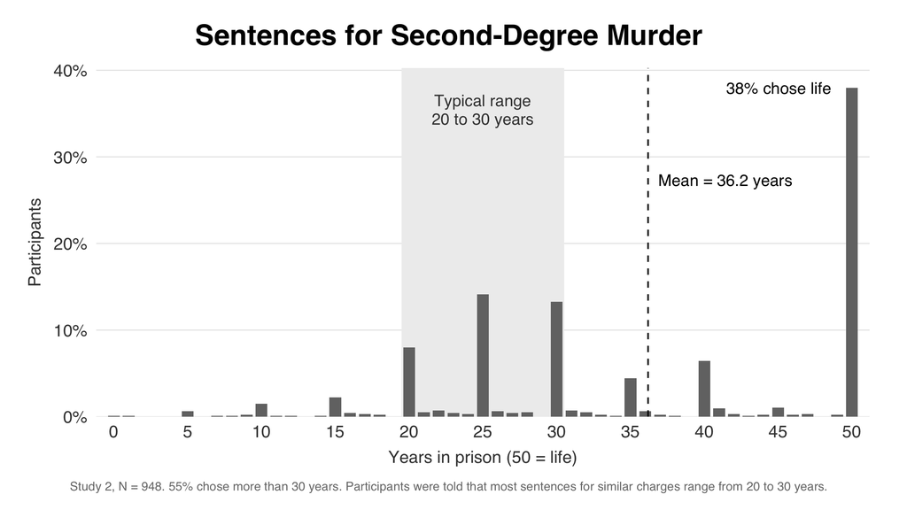

```r
keep_values("s2_01_sentences", data.frame(
  label = c("Mean first sentence (years)", "SD", "Share choosing 50",
            "Share choosing more than 30"),
  value = c(mean(s1), sd(s1), mean(s1 == 50), share_above_30),
  lower = NA, upper = NA))
fig01
```

# 4. Punitiveness and its correlates

```r
# === SLIDE 2: THE TWELVE REGISTERED CORRELATES (BAR CHART) ===
# Each attitude's correlation with the eight-item punitiveness scale, with its
# 95% interval, exactly as the registered H1 table exported them. The shade
# marks the registered cluster each attitude belongs to (01_main_analysis.Rmd,
# 4.9): hostile aggression = hatred, revenge, degradation, infliction of
# suffering, tolerance of prison violence (darkest); crime concerns = perceived
# crime rates, fear of crime (lightest). The other five belong to neither.
h1 <- read_s2("H1_correlations")
stopifnot(nrow(h1) == 12)
HOSTILE_SET <- c("Hatred", "Revenge", "Degradation", "Infliction of suffering",
                 "Tolerance of prison violence")
CRIME_SET   <- c("Perceived crime rates", "Fear of crime")
stopifnot(all(c(HOSTILE_SET, CRIME_SET) %in% h1$y))
CL_LEVELS <- c("Hostility toward offenders", "Other attitudes", "Concern about crime")
h1$cluster <- factor(ifelse(h1$y %in% HOSTILE_SET, CL_LEVELS[1],
                     ifelse(h1$y %in% CRIME_SET, CL_LEVELS[3], CL_LEVELS[2])),
                     levels = CL_LEVELS)
h1$label <- factor(h1$y, levels = h1$y[order(h1$r)])
h1$lower <- h1$ci_lower; h1$upper <- h1$ci_upper
fig02 <- bar_r(h1, "label", "cluster", fills = setNames(c(G1, G3, G4), CL_LEVELS),
               xlim = c(0, 0.83), xbreaks = seq(0, 0.8, 0.2),
               xlab = "Correlation with punitiveness (r)") +
  labs(title = "What Goes With Punitiveness",
       caption = cap("Study 2, N = 948. Error bars are 95% confidence intervals.",
                     "All twelve correlations were preregistered (H1)."))
save_slide(fig02, "s2_02_correlates")
```

```
## [1] TRUE
```

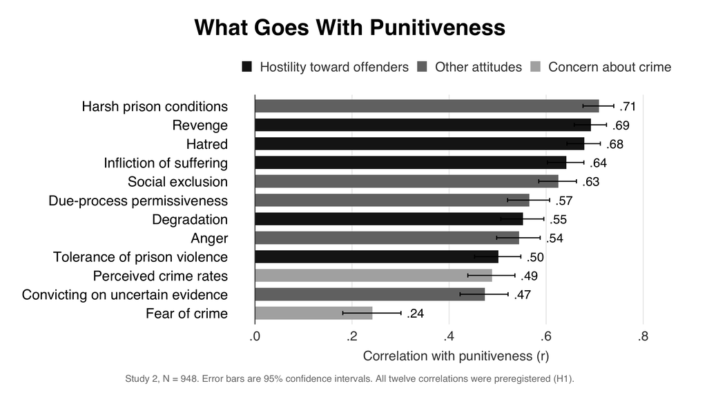

```r
keep_values("s2_02_correlates", data.frame(label = h1$y, value = h1$r,
                                           lower = h1$lower, upper = h1$upper))
fig02
```

```r
# === SLIDE 3: HOSTILITY AGAINST CRIME CONCERNS (GROUPED BAR CHART) ===
# The two registered clusters' correlations with punitiveness (the registered
# H2 comparison) and with each separate part of punitiveness. The parts are the
# five attitude parts of the eight-item scale, scored as 01_main_analysis.Rmd
# scores them in 7.6D (item pairs averaged; single items as they stand), plus
# the within-vignette standardized sentence. The clusters here are the
# REGISTERED ones (hostile_agg, crime_concerns), so this slide is Study 2 on its
# own terms; 7.6D ran the same parts on the clusters rebuilt as Study 1 built
# them, for the comparison with Study 1.
parts <- data.frame(
  punit          = d$punitiveness,
  punish_more    = rowMeans(d[, c("punishmore_1_R", "punishmore_2")]),
  parsimony_rej  = rowMeans(d[, c("parsimony_1_R", "parsimony_2_R")]),
  three_strikes  = rowMeans(d[, c("threestrikes_1", "threestrikes_2")]),
  lwop           = as.numeric(d$LWOP),
  death_penalty  = as.numeric(d$deathpenalty),
  sentence       = d$Sentence1_z)
stopifnot(!anyNA(parts), !anyNA(d$hostile_agg), !anyNA(d$crime_concerns))
PART_LABELS <- c(punit = "Punitiveness (all eight items)",
                 punish_more = "More punishment",
                 parsimony_rej = "Rejecting parsimony",
                 three_strikes = "Three strikes",
                 lwop = "Life without parole",
                 death_penalty = "Death penalty",
                 sentence = "Sentence given")
# Steiger's test with Zou's interval, called exactly as the main analysis calls
# it, for the difference between the two correlations on each outcome. Reported
# in the values table; the slide shows the two correlations themselves.
steiger_diff <- function(y, k, h) {
  r_jk <- cor(y, k); r_jh <- cor(y, h); r_kh <- cor(k, h); n <- length(y)
  res <- cocor::cocor.dep.groups.overlap(r.jk = r_jk, r.jh = r_jh, r.kh = r_kh,
                                         n = n, alternative = "greater",
                                         test = c("steiger1980", "zou2007"),
                                         return.htest = TRUE)
  z <- unname(res$steiger1980$statistic)
  data.frame(diff = r_jk - r_jh, diff_lower = res$zou2007$conf.int[1],
             diff_upper = res$zou2007$conf.int[2], z = z,
             p_two_sided = 2 * pnorm(-abs(z)))
}
h2rows <- do.call(rbind, lapply(names(PART_LABELS), function(v) {
  hk <- cor_ci(parts[[v]], d$hostile_agg); ck <- cor_ci(parts[[v]], d$crime_concerns)
  cbind(outcome = PART_LABELS[[v]], key = v,
        r_hostile = hk$r, lo_hostile = hk$lower, up_hostile = hk$upper,
        r_crime = ck$r, lo_crime = ck$lower, up_crime = ck$upper,
        steiger_diff(parts[[v]], d$hostile_agg, d$crime_concerns))
}))
# GUARDS. The punitiveness row is the registered H2 test; the sentence row is
# the registered-cluster sentence comparison 7.5 exported. Both must match.
h2_rec <- read_s2("H2_steiger")
same(h2rows$r_hostile[1], h2_rec$r_jk, "H2 hostility r")
same(h2rows$r_crime[1],   h2_rec$r_jh, "H2 crime concerns r")
same(h2rows$diff[1],      h2_rec$diff, "H2 difference")
same(h2rows$z[1],         h2_rec$z,    "H2 Steiger z")
sent_rec <- read_s2("DS_sentence_steiger")[1, ]
same(h2rows$r_hostile[7], sent_rec$r_jk, "sentence: hostility r")
same(h2rows$r_crime[7],   sent_rec$r_jh, "sentence: crime concerns r")
same(h2rows$diff[7],      sent_rec$diff, "sentence: difference")
print(h2rows[, c("outcome", "r_hostile", "r_crime", "diff", "diff_lower",
                 "diff_upper", "z", "p_two_sided")], digits = 3)
```

```
##                          outcome r_hostile r_crime  diff diff_lower diff_upper
## 1 Punitiveness (all eight items)     0.770   0.427 0.343     0.2906      0.397
## 2                More punishment     0.721   0.399 0.321     0.2666      0.377
## 3            Rejecting parsimony     0.527   0.298 0.229     0.1667      0.291
## 4                  Three strikes     0.587   0.315 0.272     0.2117      0.333
## 5            Life without parole     0.492   0.302 0.190     0.1270      0.253
## 6                  Death penalty     0.585   0.310 0.275     0.2143      0.336
## 7                 Sentence given     0.373   0.247 0.126     0.0593      0.192
##       z p_two_sided
## 1 13.65    2.04e-42
## 2 11.94    7.34e-33
## 3  7.20    5.84e-13
## 4  8.86    7.74e-19
## 5  5.90    3.68e-09
## 6  8.93    4.17e-19
## 7  3.70    2.14e-04
```

```r
SERIES3 <- c("Hostility toward offenders", "Concern about crime")
long3 <- rbind(
  data.frame(outcome = h2rows$outcome, series = SERIES3[1],
             r = h2rows$r_hostile, lower = h2rows$lo_hostile, upper = h2rows$up_hostile),
  data.frame(outcome = h2rows$outcome, series = SERIES3[2],
             r = h2rows$r_crime, lower = h2rows$lo_crime, upper = h2rows$up_crime))
long3$outcome <- factor(long3$outcome, levels = rev(unname(PART_LABELS)))
# position_dodge() places the FIRST level lowest; reversing the levels puts the
# hostility bar above the crime-concerns bar in every row, as the legend reads.
long3$series  <- factor(long3$series, levels = rev(SERIES3))
fig03 <- bar_r(long3, "outcome", "series", fills = setNames(c(G1, G4), SERIES3),
               xlim = c(0, 0.86), xbreaks = seq(0, 0.8, 0.2),
               xlab = "Correlation (r)", dodge = 0.8) +
  guides(fill = guide_legend(reverse = TRUE)) +
  labs(title = "Hostility Versus Concern About Crime",
       caption = cap("Study 2, N = 948. Hostility: hatred, revenge, degradation, suffering, prison violence.",
                     "Concern about crime: perceived crime rates, fear of crime. Error bars are 95%",
                     "confidence intervals. Preregistered for all eight items together (H2); not for the parts."))
save_slide(fig03, "s2_03_hostility_vs_crime")
```

```
## [1] TRUE
```

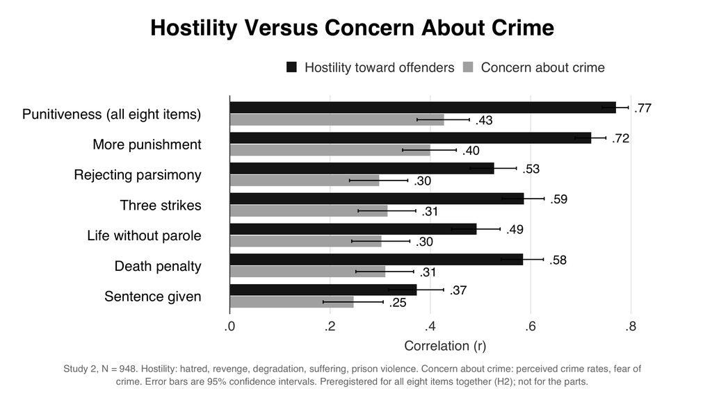

```r
keep_values("s2_03_hostility_vs_crime", rbind(
  data.frame(label = paste("Hostility:", h2rows$outcome), value = h2rows$r_hostile,
             lower = h2rows$lo_hostile, upper = h2rows$up_hostile),
  data.frame(label = paste("Crime concerns:", h2rows$outcome), value = h2rows$r_crime,
             lower = h2rows$lo_crime, upper = h2rows$up_crime),
  data.frame(label = paste("Difference (Steiger, Zou CI):", h2rows$outcome),
             value = h2rows$diff, lower = h2rows$diff_lower, upper = h2rows$diff_upper)))
fig03
```

# 5. The goals of punishment

```r
# === SLIDE 4: HOW THE FOUR GOALS WERE RANKED (STACKED BAR CHART) ===
# The share of participants placing each goal first, second, third and fourth,
# from the exported rank matrix. First place is darkest and sits at the left of
# each bar.
rk <- read_s2("goal_rank_matrix")
rk$goal <- ifelse(grepl("retribution", rk$goal), "Retribution",
           ifelse(grepl("incapacitation", rk$goal), "Incapacitation",
           ifelse(grepl("deterrence", rk$goal), "Deterrence", "Rehabilitation")))
GOAL_ORDER <- c("Retribution", "Incapacitation", "Deterrence", "Rehabilitation")
stopifnot(setequal(rk$goal, GOAL_ORDER),
          all(rowSums(rk[, c("first", "second", "third", "fourth")]) == 948))
rank_long <- do.call(rbind, lapply(c("first", "second", "third", "fourth"), function(p)
  data.frame(goal = rk$goal, place = p, pct = 100 * rk[[p]] / 948)))
PLACE_LAB <- c(first = "Ranked 1st", second = "2nd", third = "3rd", fourth = "4th (last)")
rank_long$place <- factor(PLACE_LAB[rank_long$place], levels = PLACE_LAB)
rank_long$goal  <- factor(rank_long$goal, levels = rev(GOAL_ORDER))
fig04 <- ggplot(rank_long, aes(x = pct, y = goal, fill = place)) +
  # position_stack(reverse = TRUE) puts 1st place at the left of each bar.
  geom_col(width = 0.7, colour = "white", linewidth = 1,
           position = position_stack(reverse = TRUE)) +
  # group = place makes the labels stack in the same order as the bars; without
  # it, the colour mapping would regroup them and misplace every label.
  geom_text(aes(label = sprintf("%.0f%%", pct), group = place,
                colour = place %in% PLACE_LAB[1:3]),
            position = position_stack(vjust = 0.5, reverse = TRUE), size = 6.5,
            show.legend = FALSE) +
  scale_colour_manual(values = c(`TRUE` = "white", `FALSE` = INK), guide = "none") +
  scale_fill_manual(values = setNames(RAMP4, PLACE_LAB)) +
  scale_x_continuous(expand = expansion(mult = c(0, 0.01))) +
  labs(title = "Ranking the Goals of Punishment", x = NULL, y = NULL,
       caption = cap("Study 2, N = 948. Participants ranked four reasons for punishment from best to weakest:",
                     "\"Criminals deserve to be punished\" (retribution); \"While they are locked up, prisoners",
                     "cannot commit other crimes\" (incapacitation); \"Punishment deters others from committing",
                     "crimes\" (deterrence); \"Prisoners get rehabilitated in prison\" (rehabilitation).")) +
  theme_hbar() +
  theme(panel.grid.major.x = element_blank(), axis.text.x = element_blank())
save_slide(fig04, "s2_04_ranking")
```

```
## [1] TRUE
```

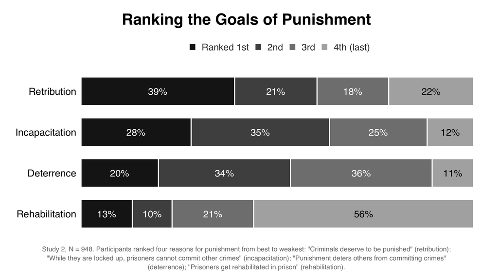

```r
keep_values("s2_04_ranking", data.frame(
  label = paste(rank_long$goal, rank_long$place), value = rank_long$pct / 100,
  lower = NA, upper = NA))
fig04
```

```r
# === SLIDE 5: HOW THE FOUR GOALS WERE RATED (VIOLIN PLOT) ===
# Each goal scale (the mean of its items, 1 to 7), one violin per goal, with the
# mean and its 95% interval. The means are checked against the exported ones.
GOAL_KEY <- c(retribution = "Retribution", incapacitation = "Incapacitation",
              deterrence = "Deterrence", rehabilitation = "Rehabilitation")
for (v in names(GOAL_KEY)) stopifnot(!anyNA(d[[v]]))
rating <- do.call(rbind, lapply(names(GOAL_KEY), function(v)
  cbind(measure = GOAL_KEY[[v]], mean_ci(d[[v]]))))
gs <- read_s2("goal_subscales")
for (v in names(GOAL_KEY))
  same(rating$mean[rating$measure == GOAL_KEY[[v]]],
       gs$mean[grepl(paste0("^", v), gs$measure)], paste("rating mean,", v))
rating_long <- do.call(rbind, lapply(names(GOAL_KEY), function(v)
  data.frame(measure = GOAL_KEY[[v]], score = d[[v]])))
fig05 <- violin_1to7(rating_long, rating, unname(GOAL_KEY)) +
  labs(title = "Rating the Goals of Punishment",
       caption = cap("Study 2, N = 948. Each goal rated on its own, 1 to 7. Small points are participants; large points are",
                     "means with 95% confidence intervals. Ratings came before the ranking."))
save_slide(fig05, "s2_05_ratings")
```

```
## [1] TRUE
```

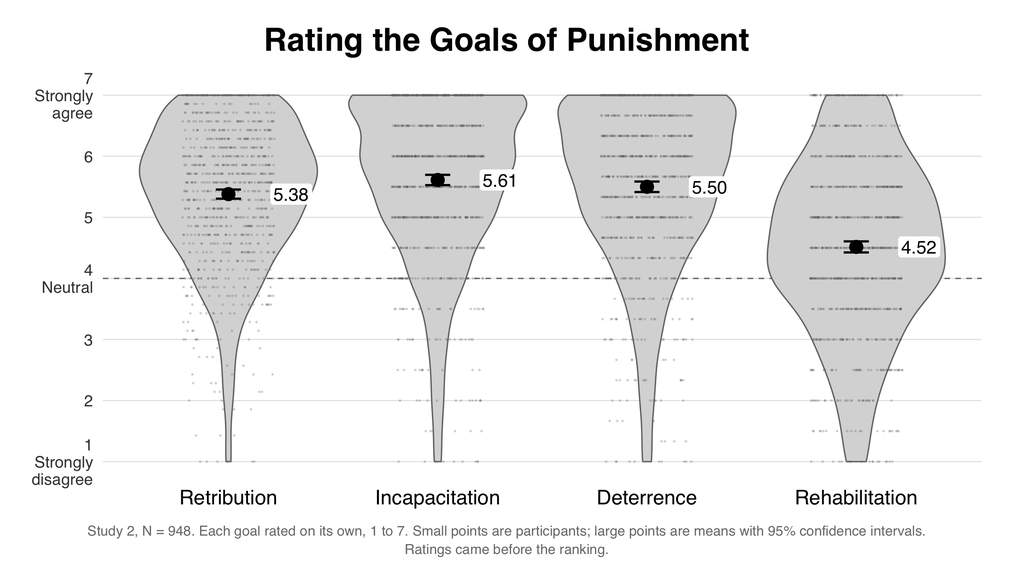

```r
keep_values("s2_05_ratings", data.frame(label = paste("Rating:", rating$measure),
                                        value = rating$mean, lower = rating$lower,
                                        upper = rating$upper))
fig05
```

# 6. Proportionality

```r
# === SLIDE 6: AGREEMENT WITH PROPORTIONALITY AND ITS DEPARTURES (STACKED BARS) ===
# For each of the three items, the share who disagreed (1-3), were neutral (4),
# or agreed (5-7). Items are raw, as answered.
ITEMS6 <- c(proportionality = "\"Punishment should be proportionate to the\nseverity of the crime, no more and no less\"",
            severity_1 = "\"Punishment should be greater than\nthe seriousness of the crime\"",
            severity_2 = "\"Punishment should be less severe than\nthe harmfulness of the crime\"")
for (v in names(ITEMS6)) stopifnot(!anyNA(d[[v]]), all(d[[v]] %in% 1:7))
# GUARDS against the registered H4 and H5 exports.
h4 <- read_s2("H4_midpoint_tests"); h4s <- read_s2("H4_shares"); h5 <- read_s2("H5_paired")
same(mean(d$proportionality), h4$mean[h4$variable == "proportionality"], "proportionality mean")
same(mean(d$severity_1), h5$M1, "severity_1 mean")
same(mean(d$severity_2), h5$M2, "severity_2 mean")
same(sum(d$proportionality <= 4), h4s$k[3], "proportionality at or below 4")
same(sum(d$severity_1 > 4), h4s$k[1], "severity_1 above 4")
AGREE_LEV <- c("Disagree", "Neutral", "Agree")
prop_long <- do.call(rbind, lapply(names(ITEMS6), function(v) data.frame(
  item = ITEMS6[[v]], answer = AGREE_LEV,
  pct = 100 * c(mean(d[[v]] < 4), mean(d[[v]] == 4), mean(d[[v]] > 4)))))
prop_long$item   <- factor(prop_long$item, levels = rev(unname(ITEMS6)))
prop_long$answer <- factor(prop_long$answer, levels = AGREE_LEV)
fig06 <- ggplot(prop_long, aes(x = pct, y = item, fill = answer)) +
  geom_col(width = 0.66, colour = "white", linewidth = 1,
           position = position_stack(reverse = TRUE)) +
  geom_text(data = prop_long[prop_long$pct >= 5, ],
            aes(label = sprintf("%.0f%%", pct), group = answer,
                colour = answer != "Neutral"),
            position = position_stack(vjust = 0.5, reverse = TRUE), size = 6.5,
            show.legend = FALSE) +
  scale_colour_manual(values = c(`TRUE` = "white", `FALSE` = INK), guide = "none") +
  scale_fill_manual(values = c(Disagree = G3, Neutral = "#d0d0d0", Agree = G1)) +
  scale_x_continuous(expand = expansion(mult = c(0, 0.01))) +
  labs(title = "Agreement With Proportionality", x = NULL, y = NULL,
       caption = cap("Study 2, N = 948. Disagree: 1 to 3 on the 7-point scale; neutral: 4; agree: 5 to 7.",
                     "Shares under 5% are not labeled.")) +
  theme_hbar() +
  theme(panel.grid.major.x = element_blank(), axis.text.x = element_blank(),
        axis.text.y = element_text(size = 17, colour = INK, lineheight = 0.95))
save_slide(fig06, "s2_06_proportionality")
```

```
## [1] TRUE
```

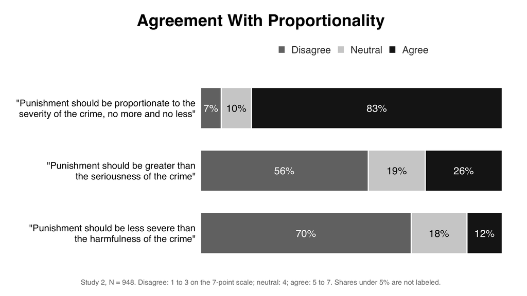

```r
keep_values("s2_06_proportionality", data.frame(
  label = paste(gsub("\n", " ", prop_long$item), prop_long$answer),
  value = prop_long$pct / 100, lower = NA, upper = NA))
fig06
```

```r
# === SLIDE 7: WHAT DESERT AND PUNITIVENESS GO WITH (GROUPED BAR CHART) ===
# Desert (R1-R4) and the eight-item punitiveness scale, each correlated with the
# proportionality principle, the severity index, and each of the index's two
# items. All values are exported (8.3b and 7.1) and checked against the data.
# Unregistered; intervals are two-sided.
h6b <- read_s2("H6b_desert_principle_vs_severity")
comp <- read_s2("H1_companion_severity")
MEAS7 <- c("No more, no less\n(proportionality principle)",
           "Never below the offense\n(severity index)",
           "More than the crime",
           "Not less than the harm")
des <- data.frame(series = "Desert", measure = MEAS7,
                  r = h6b$r[1:4], lower = h6b$ci_lower[1:4], upper = h6b$ci_upper[1:4])
pun <- data.frame(series = "Punitiveness", measure = MEAS7,
                  r = c(h6b$r[6], h6b$r[5], comp$r[2], comp$r[3]),
                  lower = c(h6b$ci_lower[6], h6b$ci_lower[5], comp$ci_lower[2], comp$ci_lower[3]),
                  upper = c(h6b$ci_upper[6], h6b$ci_upper[5], comp$ci_upper[2], comp$ci_upper[3]))
# GUARDS: recompute each correlation from the scored data.
same(des$r, c(cor(d$deserved, d$proportionality_principle), cor(d$deserved, d$severity_index),
              cor(d$deserved, d$severity_1), cor(d$deserved, d$severity_2_R)), "desert rows")
same(pun$r, c(cor(d$punitiveness, d$proportionality_principle), cor(d$punitiveness, d$severity_index),
              cor(d$punitiveness, d$severity_1), cor(d$punitiveness, d$severity_2_R)), "punitiveness rows")
SERIES7 <- c("Desert", "Punitiveness")
long7 <- rbind(des, pun)
long7$measure <- factor(long7$measure, levels = rev(MEAS7))
long7$series  <- factor(long7$series, levels = rev(SERIES7))
fig07 <- bar_r(long7, "measure", "series", fills = setNames(c(G1, G4), SERIES7),
               xlim = c(-0.08, 0.72), xbreaks = seq(0, 0.6, 0.2),
               xlab = "Correlation (r)", dodge = 0.8) +
  guides(fill = guide_legend(reverse = TRUE)) +
  labs(title = "What Desert Goes With",
       caption = cap("Study 2, N = 948. Desert: four items on punishment as deserved. \"More than the crime\":",
                     "punishment should be greater than the seriousness of the crime. \"Not less than the harm\":",
                     "rejecting punishment less severe than the harm. Not preregistered. Error bars are 95%",
                     "confidence intervals.")) +
  theme(axis.text.y = element_text(size = 17, colour = INK, lineheight = 0.95))
save_slide(fig07, "s2_07_desert_direction")
```

```
## [1] TRUE
```

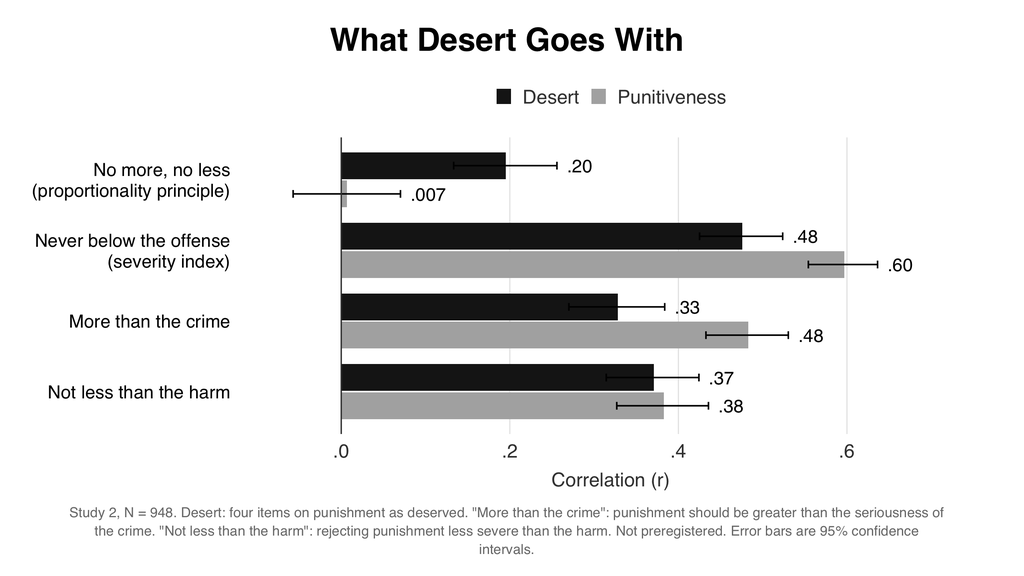

```r
keep_values("s2_07_desert_direction", data.frame(
  label = paste(long7$series, "with", gsub("\n", " ", long7$measure)), value = long7$r,
  lower = long7$lower, upper = long7$upper))
fig07
```

```r
# === SLIDE 8: EACH GOAL AGAINST EACH LIMIT (GROUPED BAR CHART) ===
# From the 4 x 4 grid of 8.9B, the two limit scores: parsimony (both items), the
# limit consequentialist theory sets, and the proportionality component (three
# items), the limit retributive theory sets. Bars below zero mean that the more
# people endorse the goal, the less they accept the limit. The single-item rows
# of 8.9B are in the values table.
gl <- read_s2("P2_goals_by_limits")
stopifnot(nrow(gl) == 16)
LIM8 <- c("Parsimony (2 items)" = "Parsimony",
          "Proportionality component (3 items)" = "Proportionality")
gl$goal <- ifelse(gl$x == "Desert (R1-R4)", "Desert", gl$x)
same(gl$r[gl$goal == "Desert" & gl$y == "Proportionality component (3 items)"],
     cor(d$deserved, d$proportionality_jd), "desert x proportionality component (H6)")
g8 <- gl[gl$y %in% names(LIM8), ]
g8$limit <- factor(LIM8[g8$y], levels = unname(LIM8))
g8$goal  <- factor(g8$goal, levels = c("Desert", "Deterrence", "Incapacitation",
                                       "Rehabilitation"))
stopifnot(nrow(g8) == 8, !anyNA(g8$limit), !anyNA(g8$goal))
DODGE8 <- position_dodge(width = 0.8)
fig08 <- ggplot(g8, aes(x = goal, y = r, fill = limit)) +
  geom_hline(yintercept = 0, colour = INK2, linewidth = 0.7) +
  geom_col(width = 0.76, position = DODGE8) +
  geom_errorbar(aes(ymin = ci_lower, ymax = ci_upper), width = 0.2,
                linewidth = 0.7, colour = INK, position = DODGE8) +
  # Each value sits just beyond the end of its interval, above a bar that
  # points up and below a bar that points down.
  geom_text(aes(y = ifelse(r >= 0, ci_upper + 0.025, ci_lower - 0.025),
                vjust = ifelse(r >= 0, 0, 1), label = fmt_r(r)),
            position = DODGE8, size = 6, colour = INK) +
  scale_fill_manual(values = c(Parsimony = G1, Proportionality = G4)) +
  scale_y_continuous(breaks = seq(-0.5, 0.2, 0.1), labels = axis_r) +
  coord_cartesian(ylim = c(-0.56, 0.22), clip = "off") +
  labs(title = "Goals of Punishment and Their Limits", x = NULL,
       y = "Correlation with the limit (r)",
       caption = cap("Study 2, N = 948. Parsimony: \"Criminal punishments should be as light as possible\";",
                     "\"The state should not punish more than is absolutely necessary.\" Proportionality: the",
                     "three-item component. Only desert with proportionality was preregistered (H6).",
                     "Error bars are 95% confidence intervals.")) +
  theme_vbar()
save_slide(fig08, "s2_08_goals_vs_limits")
```

```
## [1] TRUE
```

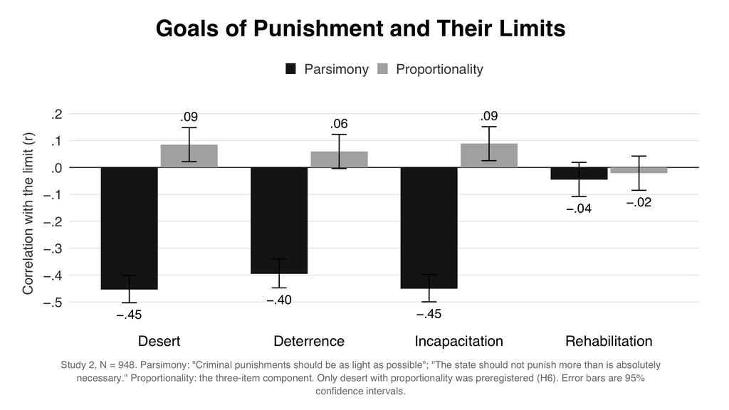

```r
keep_values("s2_08_goals_vs_limits", data.frame(
  label = paste(gl$goal, "x", gl$y), value = gl$r, lower = gl$ci_lower, upper = gl$ci_upper))
fig08
```

# 7. Desert and revenge

```r
# === SLIDE 9: HOW MUCH PEOPLE ENDORSE DESERT AND REVENGE (VIOLIN PLOT) ===
# Desert, just deserts and revenge, each a mean of items on a 1-to-7 scale, one
# violin each, with the mean and its 95% interval. Means are checked against
# the registered H9 export.
ENDORSE <- c(deserved = "Desert", just_deserts = "Just deserts", revenge = "Revenge")
endorse <- do.call(rbind, lapply(names(ENDORSE), function(v)
  cbind(measure = ENDORSE[[v]], mean_ci(d[[v]]))))
h9 <- read_s2("H9_paired")
same(endorse$mean[1], h9$M1[2], "desert mean"); same(endorse$mean[2], h9$M1[1], "just deserts mean")
same(endorse$mean[3], h9$M2[1], "revenge mean")
endorse_long <- do.call(rbind, lapply(names(ENDORSE), function(v)
  data.frame(measure = ENDORSE[[v]], score = d[[v]])))
fig09 <- violin_1to7(endorse_long, endorse, unname(ENDORSE)) +
  labs(title = "Endorsing Desert and Revenge",
       caption = cap("Study 2, N = 948. Desert: four items on punishment as deserved. Just deserts: desert",
                     "averaged with the proportionality component. Revenge: four items. Small points are participants;",
                     "large points are means with 95% confidence intervals. Preregistered comparison: H9."))
save_slide(fig09, "s2_09_endorsement")
```

```
## [1] TRUE
```

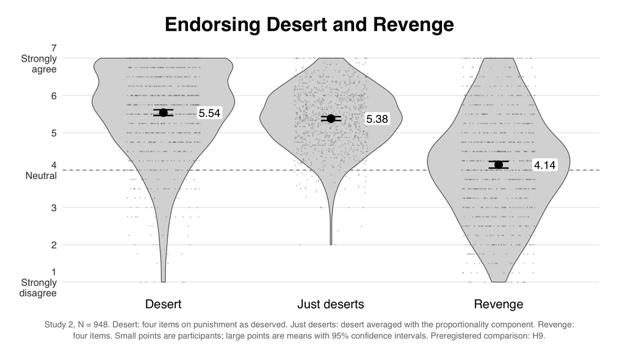

```r
keep_values("s2_09_endorsement", data.frame(label = paste("Mean:", endorse$measure),
                                            value = endorse$mean, lower = endorse$lower,
                                            upper = endorse$upper))
fig09
```

```r
# === SLIDE 10: HOW CLOSELY EACH TRACKS PUNITIVENESS (BAR CHART) ===
# Correlation of desert, just deserts, and two scorings of revenge with the
# eight-item punitiveness scale. Each r is checked against the export holding it.
d$revenge_literal <- rowMeans(d[, c("revenge_1", "revenge_2")])
stopifnot(!anyNA(d$revenge_literal))
ASSOC <- c(deserved = "Desert", just_deserts = "Just deserts",
           revenge = "Revenge (all four items)", revenge_literal = "Revenge (two literal items)")
assoc <- do.call(rbind, lapply(names(ASSOC), function(v)
  cbind(measure = ASSOC[[v]], cor_ci(d$punitiveness, d[[v]]))))
hv <- read_s2("P2_H10_vs_desert"); rv <- read_s2("H10r_revenge_versions")
same(assoc$r[1], hv$r_jh[2], "desert x punitiveness")
same(assoc$r[2], hv$r_jh[1], "just deserts x punitiveness")
same(assoc$r[3], rv$r_punit_revenge[1], "revenge x punitiveness")
same(assoc$r[4], rv$r_punit_revenge[4], "literal revenge x punitiveness")
assoc$family  <- factor(ifelse(grepl("^Revenge", assoc$measure), "Revenge",
                               "Desert and just deserts"),
                        levels = c("Desert and just deserts", "Revenge"))
assoc$measure <- factor(assoc$measure, levels = rev(unname(ASSOC)))
fig10 <- bar_r(assoc, "measure", "family",
               fills = c("Desert and just deserts" = G1, Revenge = G4),
               xlim = c(0, 0.8), xbreaks = seq(0, 0.8, 0.2),
               xlab = "Correlation with punitiveness (r)") +
  labs(title = "Desert, Revenge, and Punitiveness",
       caption = cap("Study 2, N = 948. The literal revenge items: \"Society has the right to take revenge on",
                     "criminal offenders\"; \"Society should punish to get back at criminal offenders.\"",
                     "Error bars are 95% confidence intervals. Preregistered comparison (H10): revenge",
                     "(all four items) against just deserts."))
save_slide(fig10, "s2_10_association")
```

```
## [1] TRUE
```

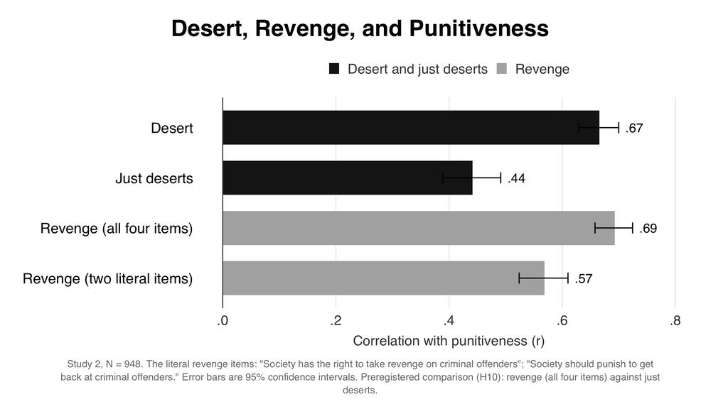

```r
keep_values("s2_10_association", data.frame(label = paste("r with punitiveness:", assoc$measure),
                                            value = assoc$r, lower = assoc$lower,
                                            upper = assoc$upper))
fig10
```

# 8. The second sentence

```r
# === SLIDE 11: FIRST AND SECOND SENTENCES (VIOLIN PLOT) ===
# Both sentences for all 948 participants, one violin each, with the mean and
# its 95% interval. Before the second sentence, participants learned that the
# offender was paralyzed and no longer a threat, and that the case would never
# be made public. Means are checked against the exported paired comparison.
s2 <- d$Sentence2
stopifnot(!anyNA(s2))
sc <- read_s2("P2_sentence_change")
same(mean(s2), sc$M1, "mean second sentence"); same(mean(s1), sc$M2, "mean first sentence")
SENT <- c("First sentence", "Second sentence")
sent_long <- rbind(data.frame(measure = SENT[1], years = s1),
                   data.frame(measure = SENT[2], years = s2))
sent_long$measure <- factor(sent_long$measure, levels = SENT)
sent_stats <- rbind(cbind(measure = SENT[1], mean_ci(s1)), cbind(measure = SENT[2], mean_ci(s2)))
sent_stats$measure <- factor(sent_stats$measure, levels = SENT)
fig11 <- ggplot(sent_long, aes(x = measure, y = years)) +
  geom_violin(fill = FILL_VIOLIN, colour = G3, linewidth = 0.6, width = 0.8,
              adjust = 1.4, trim = TRUE) +
  # Each point is one participant, jittered sideways only (see violin_1to7()).
  geom_point(position = position_jitter(width = 0.2, height = 0, seed = 1),
             size = 1.1, alpha = 0.3, colour = G3, stroke = 0) +
  geom_errorbar(data = sent_stats, aes(x = measure, ymin = lower, ymax = upper),
                inherit.aes = FALSE, width = 0.1, linewidth = 1, colour = INK) +
  geom_point(data = sent_stats, aes(x = measure, y = mean), inherit.aes = FALSE,
             size = 5, colour = INK) +
  geom_label(data = sent_stats, aes(x = measure, y = mean,
                                    label = sprintf("Mean = %.1f", mean)),
             inherit.aes = FALSE, nudge_x = 0.2, hjust = 0, size = 6,
             label.size = 0, fill = "white", label.padding = unit(0.15, "lines")) +
  scale_y_continuous(breaks = seq(0, 50, 10), limits = c(0, 50)) +
  labs(title = "First and Second Sentences", x = NULL, y = "Years in prison (50 = life)",
       caption = cap("Study 2, N = 948. Before the second sentence, participants learned that the offender",
                     "was paralyzed and no longer a threat, and that the case would never be made public.",
                     "Small points are participants; large points are means with 95% confidence intervals.",
                     "The second sentence always followed the first.")) +
  theme_vbar()
save_slide(fig11, "s2_11_two_sentences")
```

```
## [1] TRUE
```

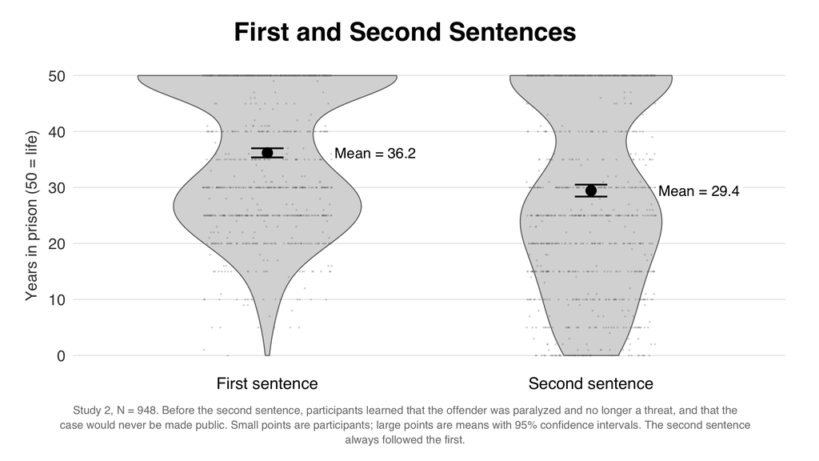

```r
keep_values("s2_11_two_sentences", data.frame(label = paste("Mean:", sent_stats$measure),
                                              value = sent_stats$mean,
                                              lower = sent_stats$lower,
                                              upper = sent_stats$upper))
fig11
```

```r
# === SLIDE 12: WHAT PARTICIPANTS DID WITH THE SECOND SENTENCE (STACKED BARS) ===
# Reduced, kept, or raised, shown separately for participants whose first
# sentence was the 50-year maximum (who could not raise it) and for those below
# it. The one participant whose first sentence was zero has no ratio and is left
# out, as in the analysis.
ok12 <- d$Sentence1 > 0
dir12 <- ifelse(d$Sentence2 < d$Sentence1, "Reduced",
         ifelse(d$Sentence2 == d$Sentence1, "Kept", "Raised"))[ok12]
GRP12 <- c("First sentence: life (50 years)", "First sentence: under 50 years")
grp12 <- ifelse(d$Sentence1[ok12] == 50, GRP12[1], GRP12[2])
tab12 <- table(factor(grp12, levels = GRP12),
               factor(dir12, levels = c("Reduced", "Kept", "Raised")))
print(tab12)
```

```
##
##                                   Reduced Kept Raised
##   First sentence: life (50 years)      81  279      0
##   First sentence: under 50 years      352  200     35
```

```r
# GUARDS against the exported counts and shares.
cells <- read_s2("sentencing_ratio_direction_cells")
same(colSums(tab12), cells$n, "reduced / kept / raised counts")
ce <- read_s2("P2_sentence_ceiling")
same(tab12[1, "Kept"], ce$k[1], "kept, first sentence 50")
same(tab12[2, ], ce$k[2:4], "below 50: reduced, kept, raised")
long12 <- as.data.frame(tab12); names(long12) <- c("group", "choice", "n")
long12$pct <- 100 * long12$n / ave(long12$n, long12$group, FUN = sum)
long12$group_lab <- sprintf("%s\n(n = %d)", long12$group,
                            ave(long12$n, long12$group, FUN = sum))
long12$group_lab <- factor(long12$group_lab, levels = rev(unique(long12$group_lab)))
fig12 <- ggplot(long12, aes(x = pct, y = group_lab, fill = choice)) +
  geom_col(width = 0.6, colour = "white", linewidth = 1,
           position = position_stack(reverse = TRUE)) +
  geom_text(data = long12[long12$pct >= 4, ],
            aes(label = sprintf("%.0f%%", pct), group = choice,
                colour = choice != "Reduced"),
            position = position_stack(vjust = 0.5, reverse = TRUE), size = 7,
            fontface = "bold", show.legend = FALSE) +
  scale_colour_manual(values = c(`TRUE` = "white", `FALSE` = INK), guide = "none") +
  scale_fill_manual(values = setNames(RAMP3, c("Reduced", "Kept", "Raised"))) +
  scale_x_continuous(expand = expansion(mult = c(0, 0.01))) +
  labs(title = "What People Did With the Second Sentence", x = NULL, y = NULL,
       caption = cap(sprintf(paste("Study 2, n = 947 (first sentence above zero). Overall, %.1f%% kept",
                                   "their sentence, %.1f%% reduced it, and %.1f%% raised it."),
                             cells$pct_of_rated[2], cells$pct_of_rated[1], cells$pct_of_rated[3]),
                     "This grouping was not preregistered.")) +
  theme_hbar() +
  theme(panel.grid.major.x = element_blank(), axis.text.x = element_blank(),
        axis.text.y = element_text(size = 19, colour = INK, lineheight = 0.95))
save_slide(fig12, "s2_12_second_sentence")
```

```
## [1] TRUE
```

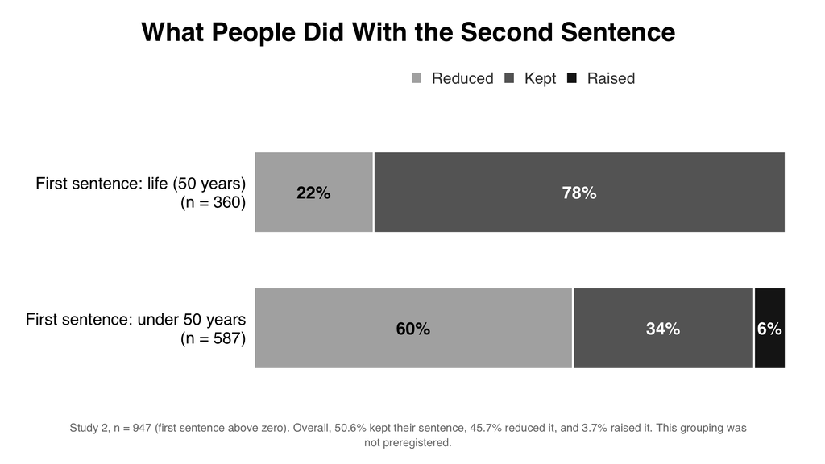

```r
keep_values("s2_12_second_sentence", data.frame(
  label = paste(long12$group, long12$choice), value = long12$pct / 100, lower = NA, upper = NA))
fig12
```

```r
# === SLIDE 13: WHAT KEEPING THE SENTENCE GOES WITH (BAR CHART) ===
# The sentencing ratio (second sentence / first) correlated with desert, revenge,
# punitiveness and the proportionality principle, each with its Fisher 95%
# interval. Every r is checked against the export that holds it.
MEAS13 <- c(deserved = "Desert", revenge = "Revenge", punitiveness = "Punitiveness",
            proportionality_principle = "No more, no less\n(proportionality principle)")
rat <- do.call(rbind, lapply(names(MEAS13), function(v)
  cbind(measure = MEAS13[[v]], cor_ci(d$sentence_ratio, d[[v]]))))
stopifnot(all(rat$n == 947))
src <- read_s2("sentencing_ratio_correlates"); cc <- read_s2("contrasts_continuous_ratio")
same(rat$r[1], src$r[1], "ratio x desert")
same(rat$r[4], src$r[4], "ratio x proportionality principle")
same(rat$r[2], cc$beta[cc$outcome == "Revenge"], "ratio x revenge", tol = 1e-6)
same(rat$r[3], cc$beta[grepl("^Punitiveness", cc$outcome)], "ratio x punitiveness", tol = 1e-6)
rat$measure <- factor(rat$measure, levels = rev(unname(MEAS13)))
rat$shade <- factor(ifelse(rat$measure == MEAS13[4], "light", "dark"), levels = c("dark", "light"))
fig13 <- bar_r(rat, "measure", "shade", fills = c(dark = G2, light = G4),
               xlim = c(-0.1, 0.42), xbreaks = seq(-0.1, 0.4, 0.1),
               xlab = "Correlation with the share of the sentence kept (r)") +
  theme(legend.position = "none",
        axis.text.y = element_text(size = 19, colour = INK, lineheight = 0.95)) +
  labs(title = "What Keeping the Sentence Goes With",
       caption = cap("Study 2, n = 947. Share kept: the second sentence divided by the first. Error bars are",
                     "95% confidence intervals. Desert and the proportionality principle: not preregistered;",
                     "revenge and punitiveness: from the preregistered analysis."))
save_slide(fig13, "s2_13_share_kept")
```

```
## [1] TRUE
```

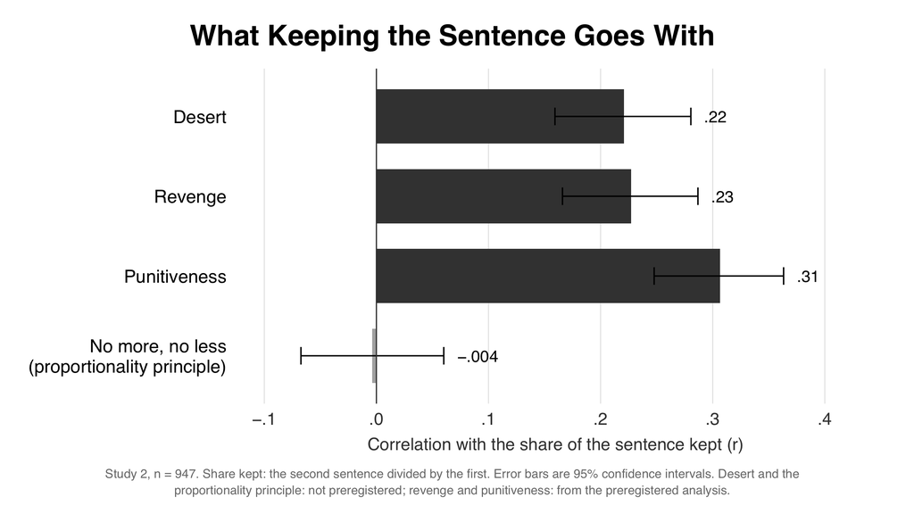

```r
keep_values("s2_13_share_kept", data.frame(label = paste("Ratio with", gsub("\n", " ", rat$measure)),
                                           value = rat$r, lower = rat$lower, upper = rat$upper))
fig13
```

# 9. What was written

```r
# EVERY PLOTTED VALUE in one table, so a number on any slide can be looked up.
vals <- do.call(rbind, VALUES)
rownames(vals) <- NULL
vals$label <- gsub("\n", " ", vals$label)
write.csv(vals, file.path(OUT_TABLES, "study2_talk_figure_values.csv"), row.names = FALSE)
cat(sprintf("%d plotted values written to study2_talk_figure_values.csv\n", nrow(vals)))
```

```
## 109 plotted values written to study2_talk_figure_values.csv
```

```r
print(list.files(OUT_FIGURES))
```

```
##  [1] "s2_01_sentences.pdf"          "s2_01_sentences.png"
##  [3] "s2_02_correlates.pdf"         "s2_02_correlates.png"
##  [5] "s2_03_hostility_vs_crime.pdf" "s2_03_hostility_vs_crime.png"
##  [7] "s2_04_ranking.pdf"            "s2_04_ranking.png"
##  [9] "s2_05_ratings.pdf"            "s2_05_ratings.png"
## [11] "s2_06_proportionality.pdf"    "s2_06_proportionality.png"
## [13] "s2_07_desert_direction.pdf"   "s2_07_desert_direction.png"
## [15] "s2_08_goals_vs_limits.pdf"    "s2_08_goals_vs_limits.png"
## [17] "s2_09_endorsement.pdf"        "s2_09_endorsement.png"
## [19] "s2_10_association.pdf"        "s2_10_association.png"
## [21] "s2_11_two_sentences.pdf"      "s2_11_two_sentences.png"
## [23] "s2_12_second_sentence.pdf"    "s2_12_second_sentence.png"
## [25] "s2_13_share_kept.pdf"         "s2_13_share_kept.png"
```

```r
print(list.files(DOCS_FIG))
```

```
##  [1] "s2_01_sentences.png"          "s2_02_correlates.png"
##  [3] "s2_03_hostility_vs_crime.png" "s2_04_ranking.png"
##  [5] "s2_05_ratings.png"            "s2_06_proportionality.png"
##  [7] "s2_07_desert_direction.png"   "s2_08_goals_vs_limits.png"
##  [9] "s2_09_endorsement.png"        "s2_10_association.png"
## [11] "s2_11_two_sentences.png"      "s2_12_second_sentence.png"
## [13] "s2_13_share_kept.png"
```